# Organizational Networks Computer Lab: Application of SNA in R

Roger Leenders

11/24/2021

# The data

This data set describes a network of corporate interlocks in Scotland back in 1904-1905 (the data were compiled by Wouter de Nooy in 2001 from the Appendix of Scott & Hughes (1980)).

## Data background

The rise of industrial revolution in the nineteenth century Europe manifested in highest railways connectivity and fastest pace of industrial development in the history. The growth of Scottish heavy industry and textile industry were especially intensive back then. The development of such industries requires large scale projects which in turn require large amount of capital. Before that private families usually were the sole owners of businesses. However, for such large scale projects private families could not raise required capital independently. As a result joint stock companies emerged. Joint stock companies are owned by the shareholders, who are represented by a board of directors. This opens up the possibility of interlocking directorates, when the same directors are serving on the boards of multiple joint stock companies. By the end of the nineteenth century, joint stock companies had become the predominant form of business enterprise at the expense of private family businesses.

**References**

Scott, J., Hughes, M., & Mackenzie, J. (1980). The Anatomy of Scottish Capital: Scottish Companies and Scottish Capital, 1900-1979. Montreal: McGill-Queen’s University Press.

Nooy, W. de, Mrvar, A., & Batagelj, V. (2018). Exploratory Social Network Analysis with Pajek (3rd ed.). Cambridge University Press., Chapter 5.

# Exercise - Who is who?

## Exercise

**1)** Read `interlocks.incidence.csv` into R and create a bipartite network object of class `igraph` with two vertex types that distinguish between companies and directors and edges representing a board membership of a given company by a given director.

**2)** The companies are in the rows of the incidence matrix and the directors are the columns. How can you check this?

**3)** In `igraph`, a bipartite graph is just a regular graph, but it has a vertex attribute called *type*. This attribute is `TRUE` or `FALSE` and this is is how `igraph` distinguishes which vertex belongs to which category.

Extract this vertex attrribute from the graph object and verify that it indeed has 108 vertices from one type and 136 from the other.

Which of the two is coded as `TRUE` and which is coded as `FALSE`?

**4)** Plot the network. In `igraph` it is possible to layout a graph as a bipartite network, but that is usually not informative.

Here, make a network plot, making sure to color the vertices according to their ‘role’: make company vertices red and director vertices blue. Conveniently, R simply uses the colornames `"red"` and `"blue"` as well, so just use those names.

## Q1: Solution

```r
incidence <- read.csv("set_correct_path/interlocks.incidence.csv",
                      header = FALSE)
```

## Q2: Solution

```r
dim(incidence)
```

```
## [1] 108 136
```

```r
# There are 108 companies:
dim(company_attrs)
```

```
## [1] 108   7
```

```r
# There are 136 directors:
dim(directorate_attrs)
```

```
## [1] 136   2
```

## Q3: Solution

Discuss your solution in class.

## Q4: Solution

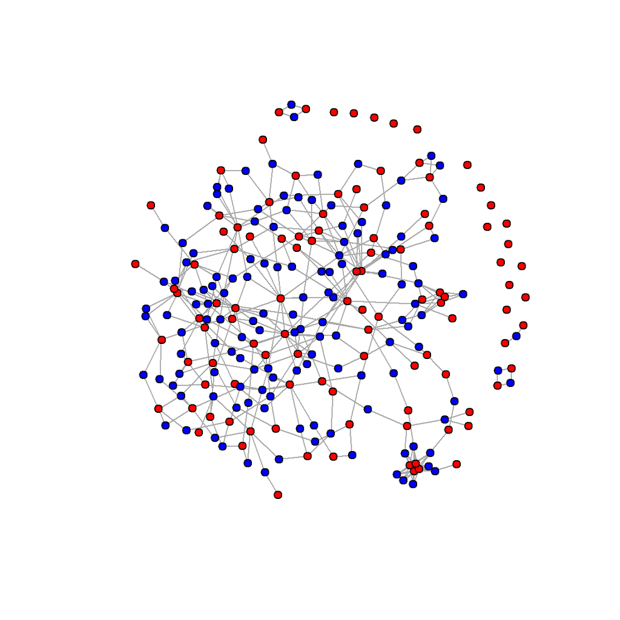

```r
company <- rep("red", 108)
director <- rep("blue", 136)
type_colors <- c(company, director)

igraph::plot.igraph(nw_bp,
                    vertex.label = NA,
                    vertex.size = 4,
                    vertex.color = type_colors)
```

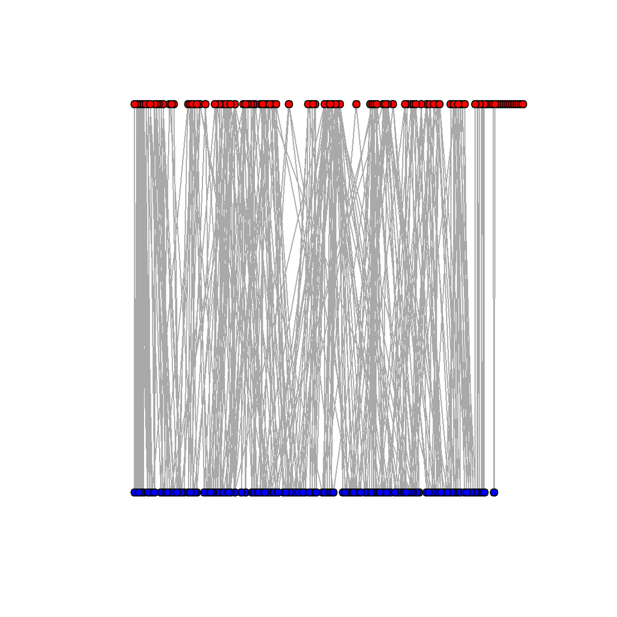

```r
# By the way, the bipartite network layout is as follows
igraph::plot.igraph(nw_bp,
                    vertex.label = NA,
                    vertex.size = 4,
                    vertex.color = type_colors,
                    layout = igraph::layout.bipartite(nw_bp))
```

```r
# Not very useful would you agree?
```

# Projection

Turn the bipartite network into two 1-mode networks:

- construct a projection where the vertices are the companies and the edges represent that two companies share one or more directors on their boards. Call this network `ig_comp` (for: *igraph company network*).
- construct a projection where the vertices are the directors and the edges represent that two directors serve in the board of the same company. Call this network `ig_direct` (for: *igraph director network*).

Ready? Now do the exercises.

# Exercise - Let’s add some attributes

## Exercises

**1)** Now, let’s add the company data to the vertices of the company network. Load `companies.attributes.csv` into R and add the name of each company, its industry, and capital to `ig_comp` as vertex attributes.

**2)** Also, add the names of the directors (from `directorate_attrs`) to `ig_direct`.

## Q1: Solution

```r
company_attrs <- read.csv("set_correct_path/companies.attributes.csv")

ig_comp <- igraph::set.vertex.attribute(ig_comp, "name", value = company_attrs$name)
ig_comp <- igraph::set.vertex.attribute(ig_comp, "industry", value = company_attrs$industry)
ig_comp <- igraph::set.vertex.attribute(ig_comp, "capital", value = company_attrs$capital)
```

## Q2: Solution

```r
directorate_attrs <- read.csv("set_correct_path/directorates.attributes.csv")

ig_direct <- igraph::set.vertex.attribute(ig_direct, "name", value = directorate_attrs$dir.name)
```

# Exploratory analysis

Let’s focus on the company network now.

- Calculate the density of the network.
- Determine the components of the network. How many are there? How are they distributed? How do you interpret this?
- Add the name/number of the component a company is a member of as a vertex attribute to the network.
- Who are the isolates? How many of them are there?
- Plot the distribution of the number of directors a company shares with others. What do you learn from this?
- If information travels **only** by shortest route, some companies will receive a larger share of information than others. Which company occupies the most informative network position? Who occupy the least informative position?
- Plot the betweenness distribution of the network. How do you interpret the result?
- Calculate the betweenness centralization of each of the three networks
- Create a graph called `ig_smaller` that consists of **only** the companies that are part of the largest component. Hint: use `igraph::induced_subgraph` for this.

# Exercise - Statistical tests

Now, we check whether the network has a regular structure or a structure that is surprising in some respect.

## Exercises

**1)** We need to use the `sna` package for this, and that only works on objects of class `network` or on matrices. Convert to an object of class `network` using the `intergraph` package. Install it, if you don’t have it yet. No network analyst should work without having that package installed.

Then convert the network using: `nw_g <- intergraph::asNetwork(ig_g)`, with the appropriate object names inserted, of course. Create `sna_comp`, `sna_smaller`, and `sna_direct`.

Then, check that the conversion indeed created the same network.

**2)** We first check for each network (`ig_smaller` and `ig_direct`) whether it has a *density* that is surprising/unexpected. Normally, you do this both for the full network and for the vertices that are member of the largest component only (so we do not consider the isolates and the loose dyads). But today, let’s only use the smaller version of the company network, because running the models takes quite some time already.

Interpret your findings.

**3)** Let’s do a similar analysis for transitivity for both networks (if running the modells takes too long, divide the models between the two of you). Again, interpret the results. Use 100 replications (to save some time).

**4)** If you have the time, analyze the betweenness centralization of the networks too. Again, use 100 replications.

## Q1: Solution

```r
sna_comp <- intergraph::asNetwork(ig_comp)
sna_smaller <- intergraph::asNetwork(ig_smaller)
sna_direct <- intergraph::asNetwork(ig_direct)
```

Do a check.

```r
# quick check
sna_comp
sna_smaller
sna::gden(sna_comp)
igraph::edge_density(ig_comp)
sna::gden(sna_smaller)
igraph::edge_density(ig_smaller)
```

## Q2: Solution (density)

Check the density conditioning on the network size. Why does this not work?

Condition on density. This won’t work for obvious reasons.

Condition on dyad census. This can’t work either! Why not?

## Q3: Solution (transitivity)

```r
cug_trans_comp_smaller <- sna::cug.test(dat = sna_smaller,
                             FUN = sna::gtrans,
                             mode = "graph",
                             reps = 100,
                             cmode = "size")

print(cug_trans_comp_smaller)
```

```
##
## Univariate Conditional Uniform Graph Test
##
## Conditioning Method: size
## Graph Type: graph
## Diagonal Used: FALSE
## Replications: 100
##
## Observed Value: 0.3547253
## Pr(X>=Obs): 1
## Pr(X<=Obs): 0
```

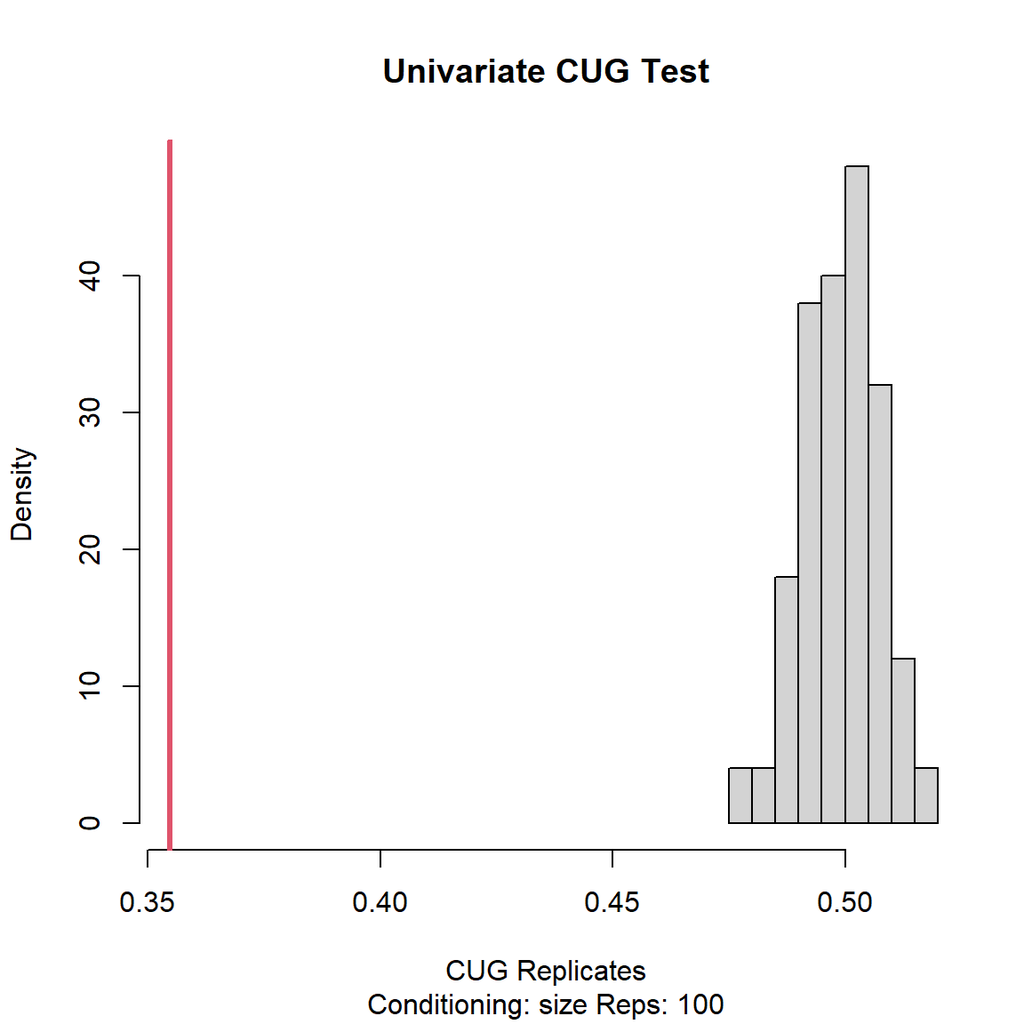

```r
plot(cug_trans_comp_smaller)
```

```r
cug_trans_comp_smaller2 <- sna::cug.test(dat = sna_smaller,
                             FUN = sna::gtrans,
                             mode = "graph",
                             reps = 100,
                             cmode = "edges")

print(cug_trans_comp_smaller2)
```

```
##
## Univariate Conditional Uniform Graph Test
##
## Conditioning Method: edges
## Graph Type: graph
## Diagonal Used: FALSE
## Replications: 100
##
## Observed Value: 0.3547253
## Pr(X>=Obs): 0
## Pr(X<=Obs): 1
```

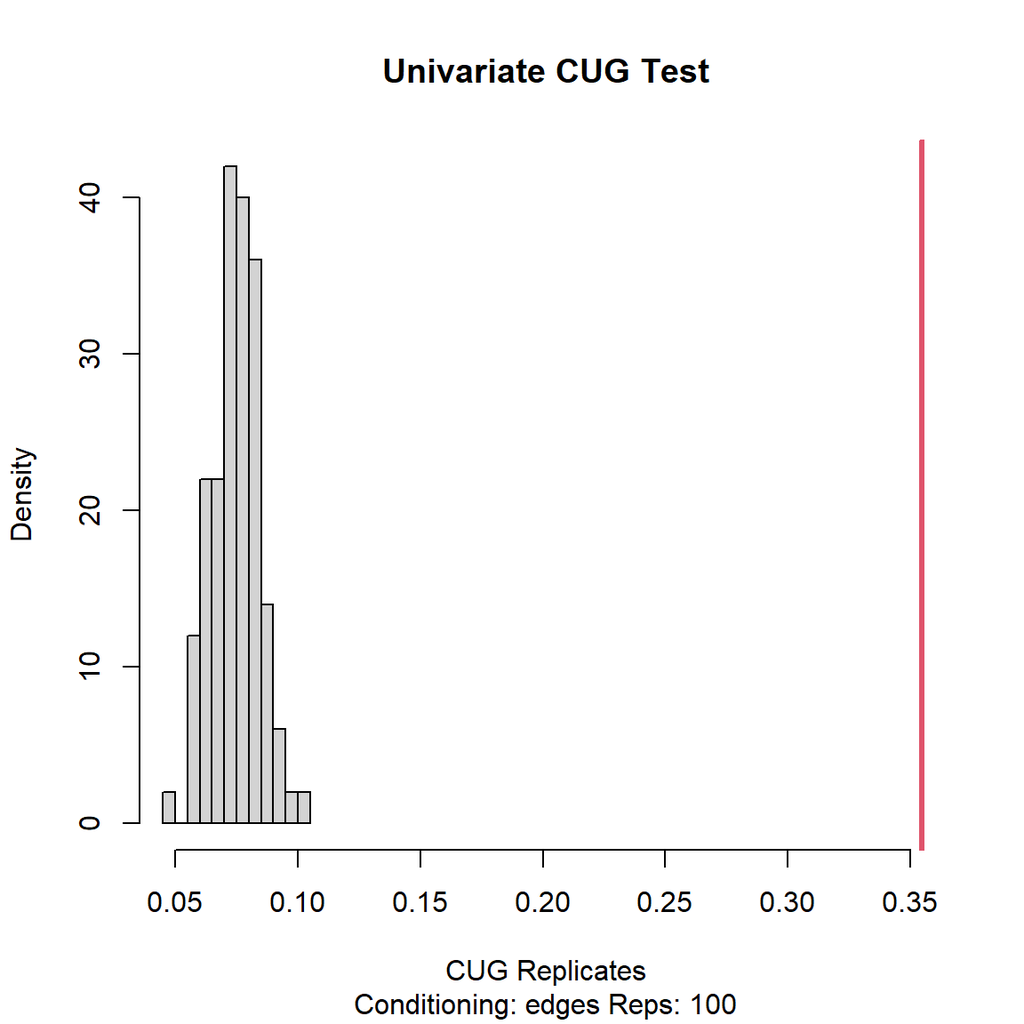

```r
plot(cug_trans_comp_smaller2)
```

```r
cug_trans_comp_smaller3 <- sna::cug.test(dat = sna_smaller,
                             FUN = sna::gtrans,
                             mode = "graph",
                             reps = 100,
                             cmode = "dyad.census")

print(cug_trans_comp_smaller3)
```

```
##
## Univariate Conditional Uniform Graph Test
##
## Conditioning Method: dyad.census
## Graph Type: graph
## Diagonal Used: FALSE
## Replications: 100
##
## Observed Value: 0.3547253
## Pr(X>=Obs): 0
## Pr(X<=Obs): 1
```

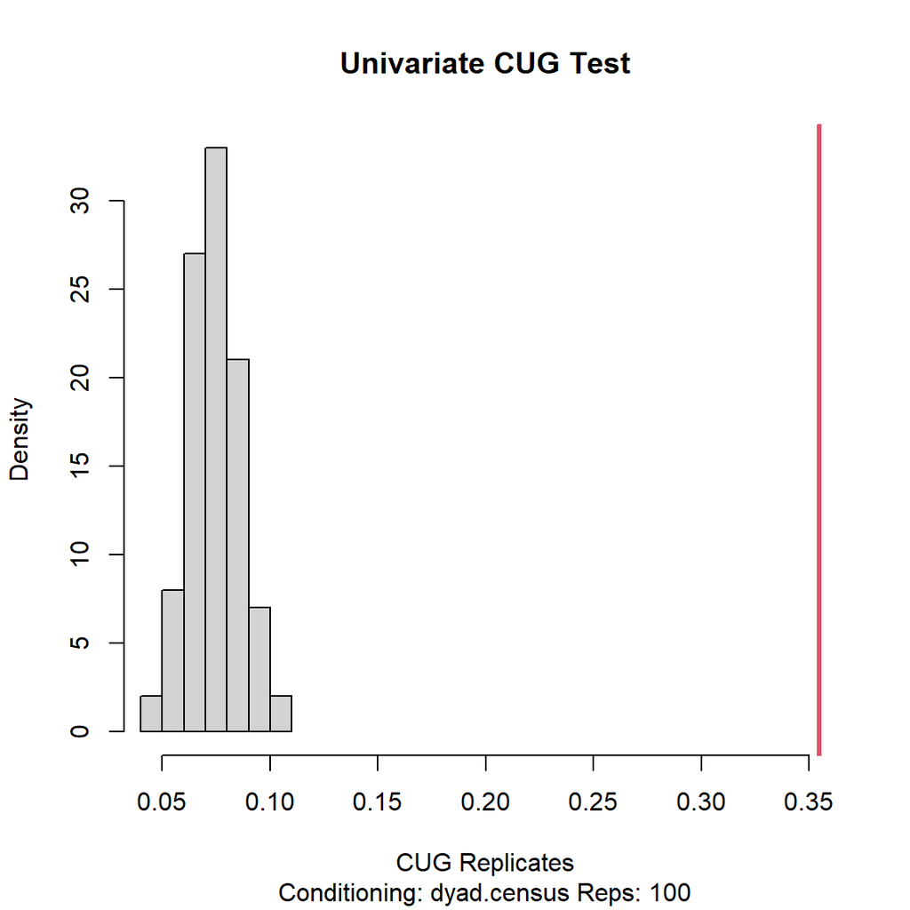

```r
plot(cug_trans_comp_smaller3)
```

Now for the director network:

```r
cug_trans_direct <- sna::cug.test(dat = sna_direct,
                             FUN = sna::gtrans,
                             mode = "graph",
                             cmode = "size")

print(cug_trans_direct)
```

```
##
## Univariate Conditional Uniform Graph Test
##
## Conditioning Method: size
## Graph Type: graph
## Diagonal Used: FALSE
## Replications: 1000
##
## Observed Value: 0.50446
## Pr(X>=Obs): 0.186
## Pr(X<=Obs): 0.814
```

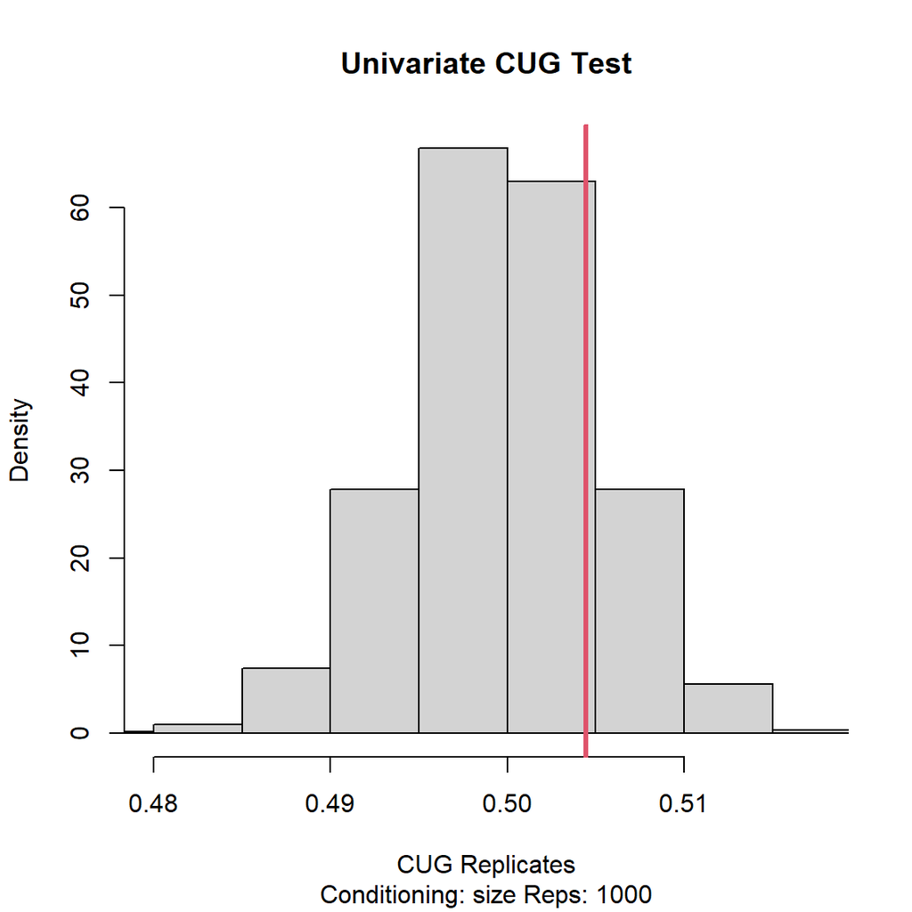

```r
plot(cug_trans_direct)
```

```r
cug_trans_direct2 <- sna::cug.test(dat = sna_direct,
                             FUN = sna::gtrans,
                             mode = "graph",
                             cmode = "edges")

print(cug_trans_direct2)
```

```
##
## Univariate Conditional Uniform Graph Test
##
## Conditioning Method: edges
## Graph Type: graph
## Diagonal Used: FALSE
## Replications: 1000
##
## Observed Value: 0.50446
## Pr(X>=Obs): 0
## Pr(X<=Obs): 1
```

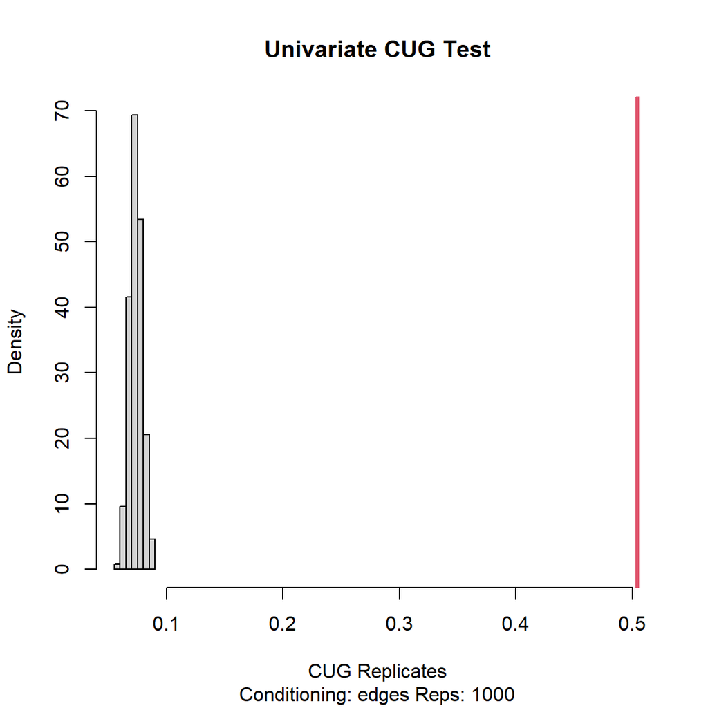

```r
plot(cug_trans_direct2)
```

```r
cug_trans_direct3 <- sna::cug.test(dat = sna_direct,
                             FUN = sna::gtrans,
                             mode = "graph",
                             cmode = "dyad.census")

print(cug_trans_direct3)
```

```
##
## Univariate Conditional Uniform Graph Test
##
## Conditioning Method: dyad.census
## Graph Type: graph
## Diagonal Used: FALSE
## Replications: 1000
##
## Observed Value: 0.50446
## Pr(X>=Obs): 0
## Pr(X<=Obs): 1
```

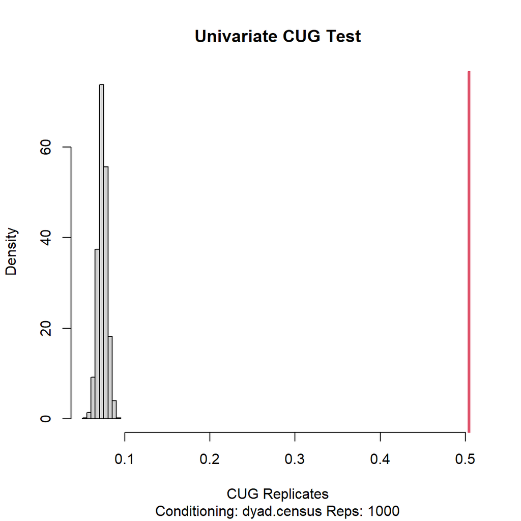

```r
plot(cug_trans_direct3)
```

## Q4: Solution (betweenness centralization)

Check the betweenness centralization conditioning on the network size, density, dyad.census.

You compute the betweenness centralization as

```r
sna::centralization(sna_comp, FUN = sna::betweenness, mode = "graph")
```

```
## [1] 0.1104604
```

This then transfers to the `cug.test` as follows:

```r
cug_betw_comp <- sna::cug.test(dat = sna_comp,
              FUN = sna::centralization,
              FUN.arg=list(FUN = sna::betweenness),
              mode="graph",
              reps = 100,
              cmode="size")
cug_betw_comp
```

```
##
## Univariate Conditional Uniform Graph Test
##
## Conditioning Method: size
## Graph Type: graph
## Diagonal Used: FALSE
## Replications: 100
##
## Observed Value: 0.1104604
## Pr(X>=Obs): 0
## Pr(X<=Obs): 1
```

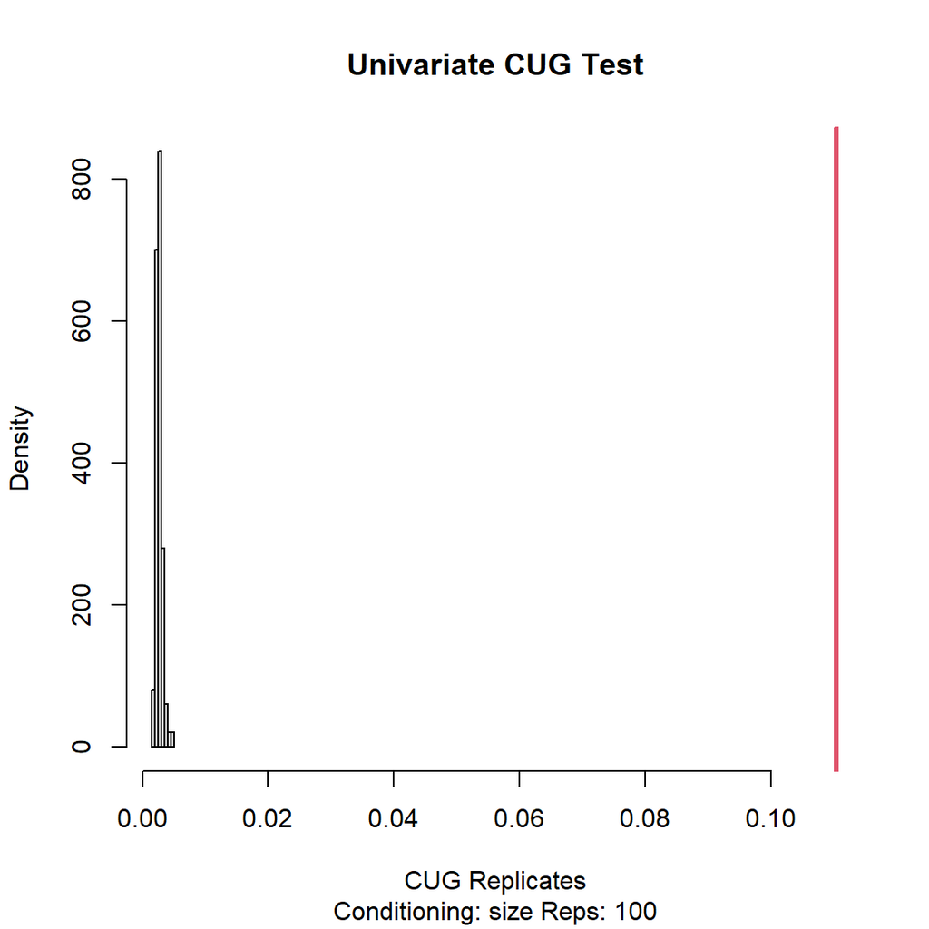

```r
plot(cug_betw_comp)
```

```r
cug_betw_comp2 <- sna::cug.test(dat = sna_comp,
              FUN = sna::centralization,
              FUN.arg=list(FUN = sna::betweenness),
              mode="graph",
              reps = 100,
              cmode="edges")
cug_betw_comp2
```

```
##
## Univariate Conditional Uniform Graph Test
##
## Conditioning Method: edges
## Graph Type: graph
## Diagonal Used: FALSE
## Replications: 100
##
## Observed Value: 0.1104604
## Pr(X>=Obs): 0.01
## Pr(X<=Obs): 0.99
```

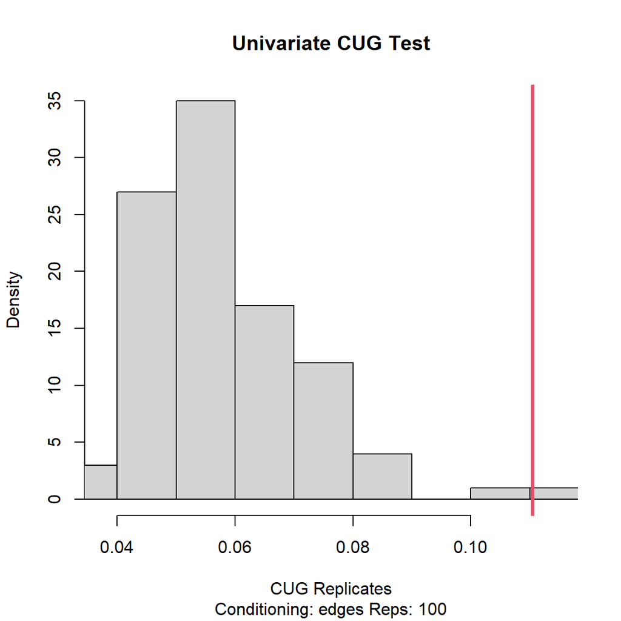

```r
plot(cug_betw_comp2)
```

```r
cug_betw_comp3 <- sna::cug.test(dat = sna_comp,
              FUN = sna::centralization,
              FUN.arg=list(FUN = sna::betweenness),
              mode="graph",
              reps = 100,
              cmode="dyad.census")
cug_betw_comp3
```

```
##
## Univariate Conditional Uniform Graph Test
##
## Conditioning Method: dyad.census
## Graph Type: graph
## Diagonal Used: FALSE
## Replications: 100
##
## Observed Value: 0.1104604
## Pr(X>=Obs): 0
## Pr(X<=Obs): 1
```

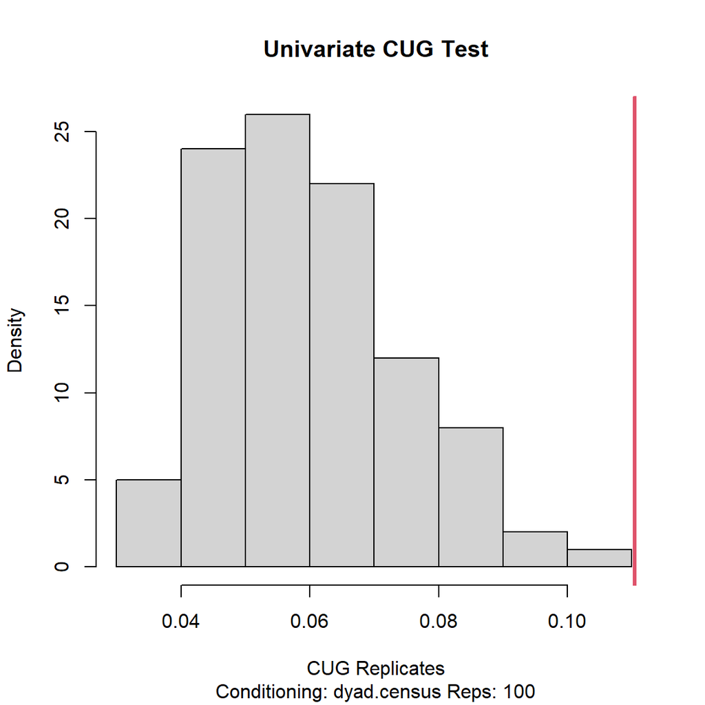

```r
plot(cug_betw_comp3)
```

For the director network:

```r
cug_betw_direct <- sna::cug.test(dat = sna_direct,
              FUN = sna::centralization,
              FUN.arg=list(FUN = sna::betweenness),
              mode="graph",
              reps = 100,
              cmode="size")
cug_betw_direct
```

```
##
## Univariate Conditional Uniform Graph Test
##
## Conditioning Method: size
## Graph Type: graph
## Diagonal Used: FALSE
## Replications: 100
##
## Observed Value: 0.1557483
## Pr(X>=Obs): 0
## Pr(X<=Obs): 1
```

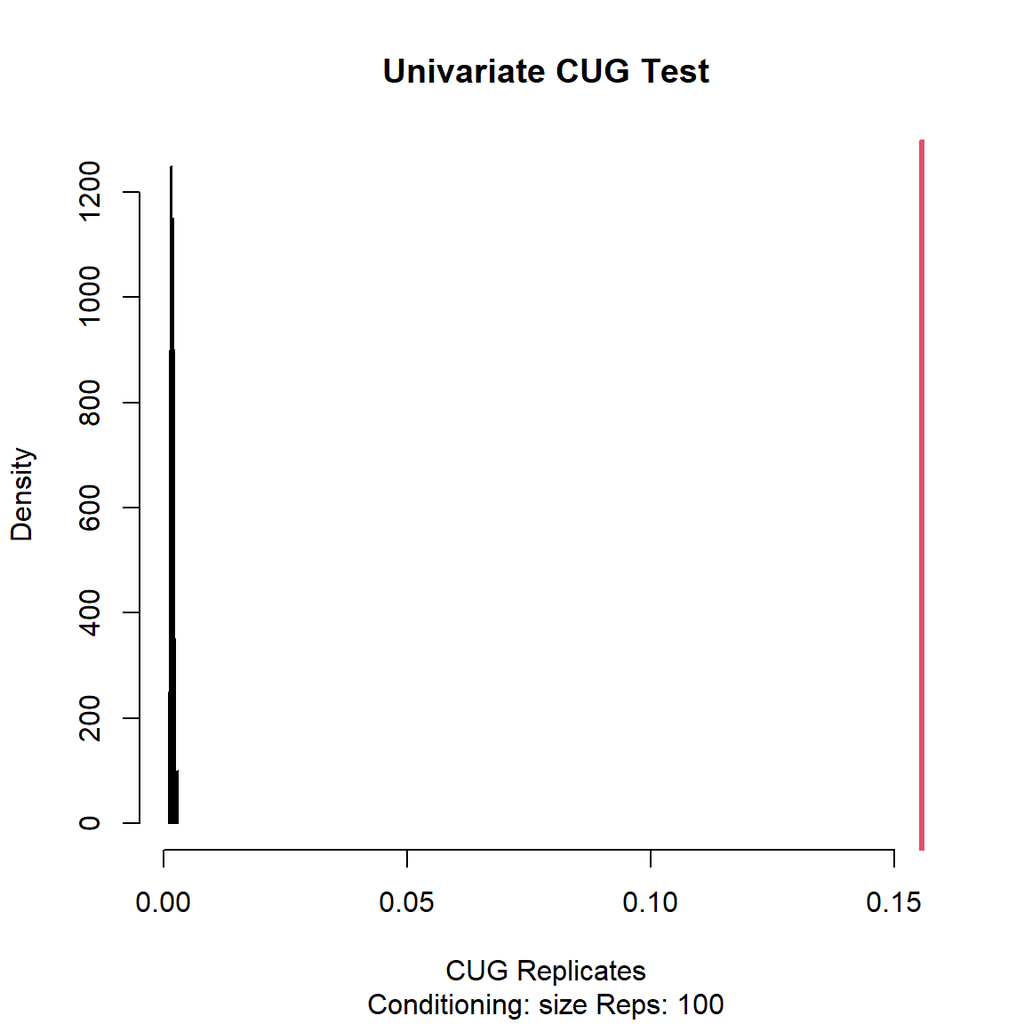

```r
plot(cug_betw_direct)
```

```r
cug_betw_direct2 <- sna::cug.test(dat = sna_direct,
                                  FUN = sna::centralization,
                                  FUN.arg=list(FUN = sna::betweenness),
                                  mode="graph",
                                  reps = 100,
                                  cmode="edges")
cug_betw_direct2
```

```
##
## Univariate Conditional Uniform Graph Test
##
## Conditioning Method: edges
## Graph Type: graph
## Diagonal Used: FALSE
## Replications: 100
##
## Observed Value: 0.1557483
## Pr(X>=Obs): 0
## Pr(X<=Obs): 1
```

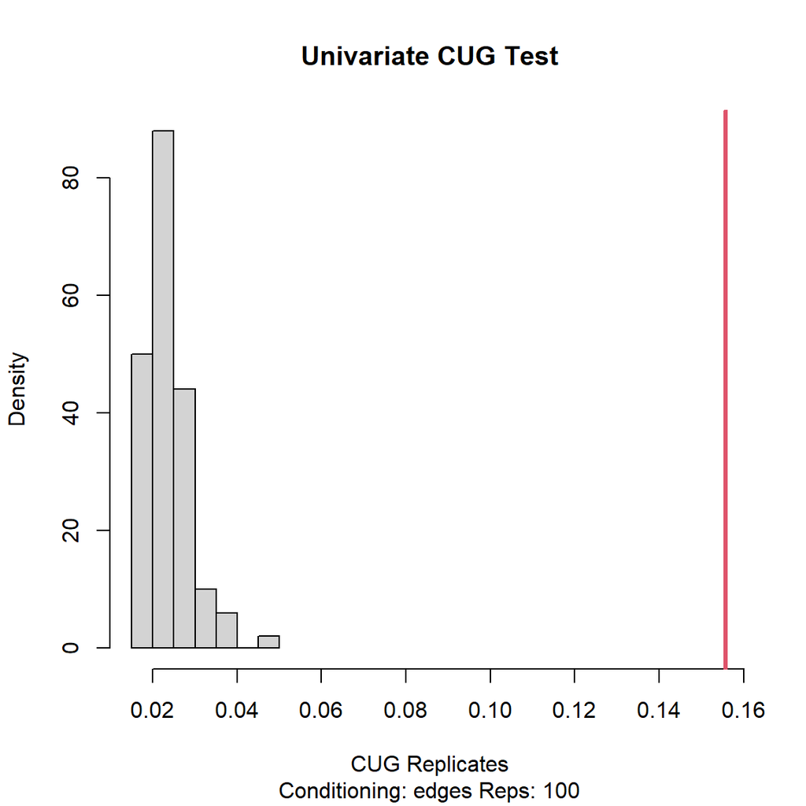

```r
plot(cug_betw_direct2)
```

```r
cug_betw_direct3 <- sna::cug.test(dat = sna_direct,
                                  FUN = sna::centralization,
                                  FUN.arg=list(FUN = sna::betweenness),
                                  mode="graph",
                                  reps = 100,
                                  cmode="dyad.census")
cug_betw_direct3
```

```
##
## Univariate Conditional Uniform Graph Test
##
## Conditioning Method: dyad.census
## Graph Type: graph
## Diagonal Used: FALSE
## Replications: 100
##
## Observed Value: 0.1557483
## Pr(X>=Obs): 0
## Pr(X<=Obs): 1
```

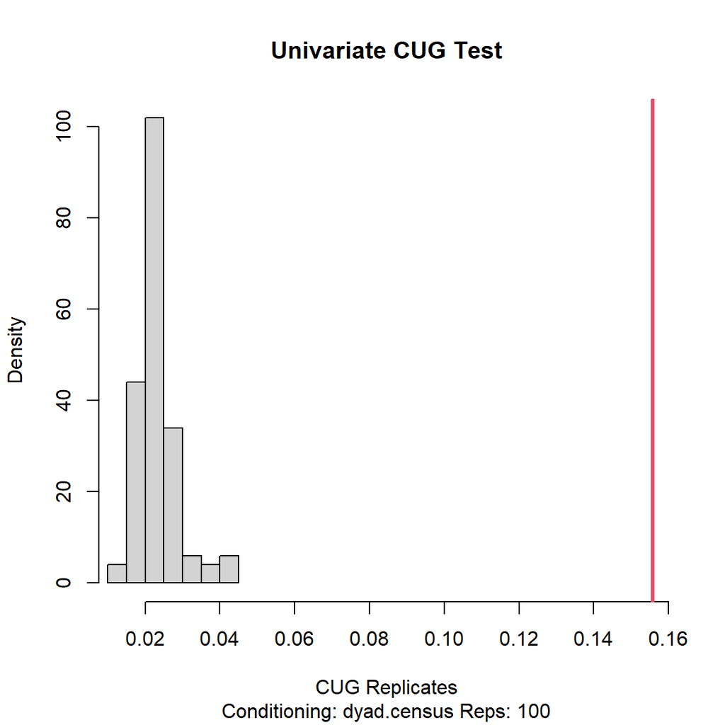

```r
plot(cug_betw_direct3)
```

# Structural equivalence

Let’s focus on a new measure: *structural equivalence*. Structural equivalence measures how similar two vertices are in terms of their network position.

Two nodes are structurally equivalent if they have **precisely** the same relations across all other nodes in the network.

Compare a and b (in red) with e and f (in black). Which pairs are more strongly structurally equivalent?

[figure not shown]

Structural equivalence is a measure of structural similarity, not of centrality. It is often used to find communities in networks or to explore how similar two organizations are in terms of their resources/input/connections.

Let’s look at that network above.

```r
edge_data <- c("a", "c",
               "a", "d",
               "a", "b",
               "b", "c",
               "b", "d",
               "c", "e",
               "d", "e",
               "e", "f",
               "f", "g",
               "f", "h",
               "g", "i",
               "g", "j",
               "h", "i",
               "h", "j",
               "i", "j")

el <- matrix(edge_data, ncol = 2, byrow = T)
net_igraph <- igraph::graph.edgelist(el, directed = F)
net_sna <- intergraph::asNetwork(net_igraph)
net_mat <- network::as.matrix.network.adjacency(net_sna)
net_mat[order(rownames(net_mat)), order(rownames(net_mat))]
```

```
##   a b c d e f g h i j
## a 0 1 1 1 0 0 0 0 0 0
## b 1 0 1 1 0 0 0 0 0 0
## c 1 1 0 0 1 0 0 0 0 0
## d 1 1 0 0 1 0 0 0 0 0
## e 0 0 1 1 0 1 0 0 0 0
## f 0 0 0 0 1 0 1 1 0 0
## g 0 0 0 0 0 1 0 0 1 1
## h 0 0 0 0 0 1 0 0 1 1
## i 0 0 0 0 0 0 1 1 0 1
## j 0 0 0 0 0 0 1 1 1 0
```

```r
diag(net_mat) <- 0  # make sure the diagonal has zeroes only
```

We calculate the structural equivalence as follows:

```r
equiv <- sna::sedist(net_sna, method = "correlation", mode = "graph")
colnames(equiv) <- rownames(equiv) <- letters[1:10]
# correlations can run from -1 to +1, now scale to [0 - 1]
equiv <- (equiv + 1)/2
diag(equiv) <- 0
round(equiv, digits = 2)
```

```
##      a    b    c    d    e    f    g    h    i    j
## a 0.00 0.67 0.67 1.00 0.73 0.20 0.20 0.20 0.20 0.20
## b 0.67 0.00 1.00 0.67 0.33 0.47 0.20 0.20 0.20 0.20
## c 0.67 1.00 0.00 0.67 0.33 0.47 0.20 0.20 0.20 0.20
## d 1.00 0.67 0.67 0.00 0.73 0.20 0.20 0.20 0.20 0.20
## e 0.73 0.33 0.33 0.73 0.00 0.33 0.47 0.47 0.20 0.20
## f 0.20 0.47 0.47 0.20 0.33 0.00 0.33 0.33 0.73 0.73
## g 0.20 0.20 0.20 0.20 0.47 0.33 0.00 1.00 0.67 0.67
## h 0.20 0.20 0.20 0.20 0.47 0.33 1.00 0.00 0.67 0.67
## i 0.20 0.20 0.20 0.20 0.20 0.73 0.67 0.67 0.00 1.00
## j 0.20 0.20 0.20 0.20 0.20 0.73 0.67 0.67 1.00 0.00
```

# Exercise - Structural equivalence

## Exercise

1. Calculate structural equivalences for the `sna_smaller` network.
2. Who are the most highly structurally equivalent organizations? (You probably do not know how to do this in R yet, but think of the *approach* you would use to do this).
3. Do you notice some special things about the result of Q2?

## Q1: Solution

```r
# don't mind the warning
equiv <- sna::sedist(sna_smaller, method = "correlation",
                      mode = "graph" )
# correlations can run from -1 to +1, now scale to [0 - 1]
equiv <- (equiv + 1)/2
diag(equiv) <- 0
```

## Q2: Solution

```r
# find the cells that have the highest value
which(equiv == max(equiv), arr.ind = TRUE)
```

```
##       row col
##  [1,]  16   7
##  [2,]  20   7
##  [3,]  21   7
##  [4,]   7  16
##  [5,]  20  16
##  [6,]  21  16
##  [7,]  35  19
##  [8,]   7  20
##  [9,]  16  20
## [10,]  21  20
## [11,]   7  21
## [12,]  16  21
## [13,]  20  21
## [14,]  45  29
## [15,]  19  35
## [16,]  74  39
## [17,]  29  45
## [18,]  82  73
## [19,]  83  73
## [20,]  39  74
## [21,]  73  82
## [22,]  83  82
## [23,]  73  83
## [24,]  82  83
```

## Q3: Solution

Let’s extract some of the network of these companies:

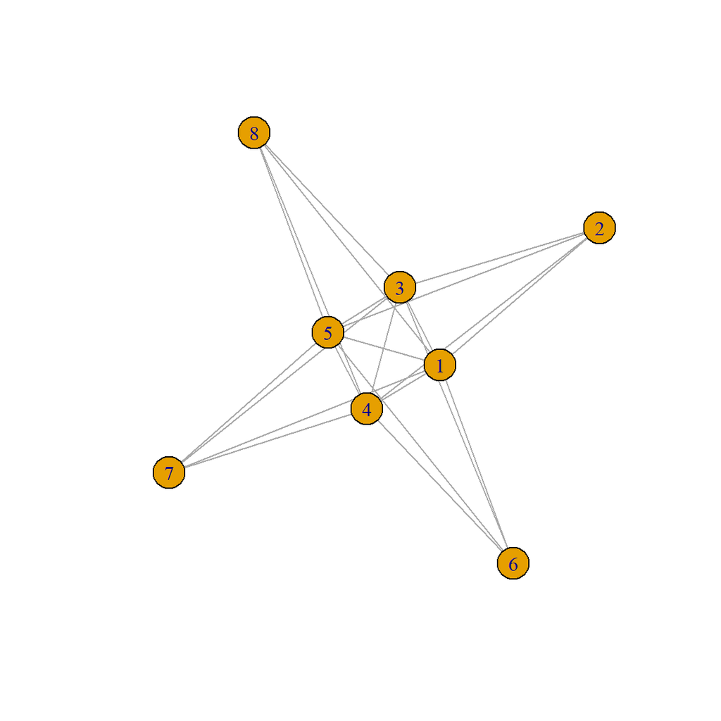

```r
# Let's look at companies 7, 16, 20, 21
edges_7 <- igraph::incident(ig_smaller, v = 7)
edges_16 <- igraph::incident(ig_smaller, v = 16)
edges_20 <- igraph::incident(ig_smaller, v = 20)
edges_21 <- igraph::incident(ig_smaller, v = 21)

igraph::subgraph.edges(ig_smaller, eids = c(edges_7, edges_16, edges_20, edges_21)) |> plot()
```

```r
# move the nodes to a nicer location
# igraph::subgraph.edges(ig_smaller, eids = c(edges_7, edges_16, edges_20, edges_21)) |> igraph::tkplot()
```

# Clusters of similar companies

If we cluster together companies that are highly structurally equivalent, we get groups of companies that are internally very similar in whom they interact with. This can be interesting for some studies. This is how you do this in a visual way.

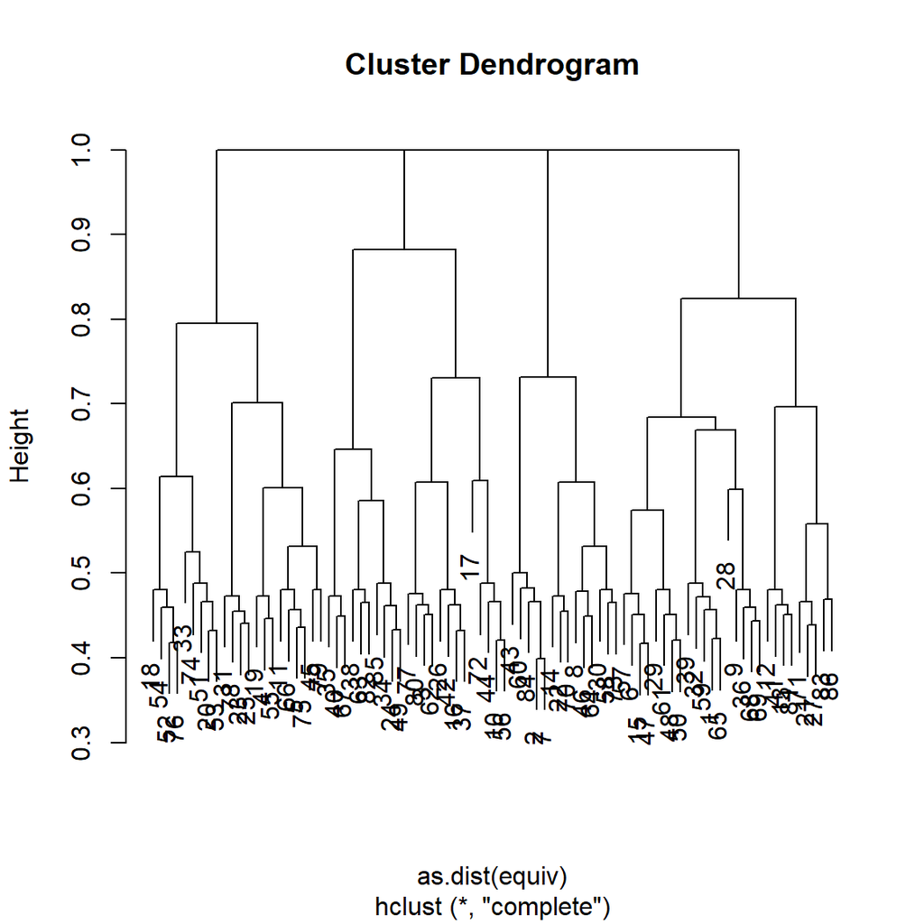

```r
# first remove the names, because they would otherwiose overwhelm
eqc <- hclust(as.dist(equiv), method = "complete")
plot(eqc)
```

Here is a cool trick: `uit <- identify(eqc)`.

Learn about this with `?stats::identify.hclust`.

# And now…

There is so much more that can be done, but let’s focus on what you need and want.

Think of research questions you want to focus on with these network data. Come up with research questions you want to study and think of how to do this. If you can’t figure out the R code, just ask!